# CA04_Spring403

## EDA

```python
import pandas as pd
import numpy as np
import matplotlib.pyplot as plt
import seaborn as sns
import math
from copy import deepcopy
from sklearn.impute import KNNImputer
from sklearn.preprocessing import StandardScaler, MinMaxScaler
from sklearn.model_selection import train_test_split
from sklearn.linear_model import LogisticRegression
from sklearn.neighbors import KNeighborsClassifier
from sklearn.tree import DecisionTreeClassifier
from sklearn.model_selection import GridSearchCV, RandomizedSearchCV
from sklearn.metrics import confusion_matrix
from sklearn.ensemble import RandomForestClassifier
from sklearn.metrics import accuracy_score, recall_score, f1_score, precision_score
from sklearn import metrics
from sklearn.metrics import ConfusionMatrixDisplay
import pandas as pd
import numpy as np
import matplotlib.pyplot as plt
import seaborn as sns
from sklearn.preprocessing import LabelEncoder
from xgboost import XGBClassifier
from sklearn.svm import SVC

from scipy import stats
```

```python
PATH = "D:/Universite/Term 6/Artificial Intelligence/CAs/CA4/DataSet.xlsx"
```

```python
df = pd.read_excel(PATH)
```

### Q1: Info and Describe

```python
df.describe()
```

|  | CRIM | ZN | INDUS | CHAS | NOX | RM | AGE | DIS | RAD | TAX | PTRATIO | B | LSTAT | MEDV |
| --- | --- | --- | --- | --- | --- | --- | --- | --- | --- | --- | --- | --- | --- | --- |
| count | 506.000000 | 506.000000 | 506.000000 | 480.000000 | 506.000000 | 506.000000 | 506.000000 | 479.000000 | 506.000000 | 506.000000 | 506.000000 | 486.000000 | 506.000000 | 452.000000 |
| mean | 1.269195 | 13.295257 | 9.205158 | 0.175000 | 1.101175 | 15.679800 | 58.744660 | 6.211663 | 78.063241 | 339.317787 | 42.614980 | 336.820947 | 11.537806 | 23.750442 |
| std | 2.399207 | 23.048697 | 7.169630 | 0.380364 | 1.646991 | 27.220206 | 33.104049 | 6.527286 | 203.542157 | 180.670077 | 87.585243 | 121.174519 | 6.064932 | 8.808602 |
| min | 0.000000 | 0.000000 | 0.000000 | 0.000000 | 0.385000 | 3.561000 | 1.137000 | 1.129600 | 1.000000 | 20.200000 | 2.600000 | 0.320000 | 1.730000 | 6.300000 |
| 25% | 0.049443 | 0.000000 | 3.440000 | 0.000000 | 0.449000 | 5.961500 | 32.000000 | 2.425900 | 4.000000 | 254.000000 | 17.000000 | 370.415000 | 6.877500 | 18.500000 |
| 50% | 0.144655 | 0.000000 | 6.960000 | 0.000000 | 0.538000 | 6.322500 | 65.250000 | 3.917500 | 5.000000 | 307.000000 | 18.900000 | 390.885000 | 10.380000 | 21.950000 |
| 75% | 0.819623 | 18.100000 | 18.100000 | 0.000000 | 0.647000 | 6.949000 | 89.975000 | 6.341400 | 24.000000 | 403.000000 | 20.200000 | 395.630000 | 15.015000 | 26.600000 |
| max | 9.966540 | 100.000000 | 27.740000 | 1.000000 | 7.313000 | 100.000000 | 100.000000 | 24.000000 | 666.000000 | 711.000000 | 396.900000 | 396.900000 | 34.410000 | 50.000000 |

```python
df.info()
```

```
<class 'pandas.core.frame.DataFrame'>
RangeIndex: 506 entries, 0 to 505
Data columns (total 14 columns):
 #   Column   Non-Null Count  Dtype
---  ------   --------------  -----
 0   CRIM     506 non-null    float64
 1   ZN       506 non-null    float64
 2   INDUS    506 non-null    float64
 3   CHAS     480 non-null    float64
 4   NOX      506 non-null    float64
 5   RM       506 non-null    float64
 6   AGE      506 non-null    float64
 7   DIS      479 non-null    float64
 8   RAD      506 non-null    int64
 9   TAX      506 non-null    float64
 10  PTRATIO  506 non-null    float64
 11  B        486 non-null    float64
 12  LSTAT    506 non-null    float64
 13  MEDV     452 non-null    float64
dtypes: float64(13), int64(1)
memory usage: 55.5 KB
```

### Q2: Missing Data Analysis

```python
df.isnull().values.any()
```

```
True
```

```python
def missing_values_table(dataframe):
    variables_with_na = [col for col in dataframe.columns if dataframe[col].isnull().sum() > 0]
    n_miss = dataframe[variables_with_na].isnull().sum().sort_values(ascending=False)
    ratio = (dataframe[variables_with_na].isnull().sum() / dataframe.shape[0] * 100).sort_values(ascending=False)
    missing_df = pd.concat([n_miss, np.round(ratio, 2)], axis=1, keys=['n_miss', 'percentage'])
    print(missing_df)
    return variables_with_na

variables_with_na = missing_values_table(df)
```

```
      n_miss  percentage
MEDV      54       10.67
DIS       27        5.34
CHAS      26        5.14
B         20        3.95
```

### Q3: Unique Values of Features

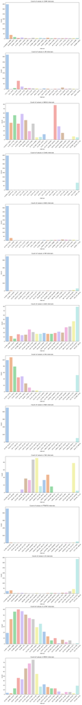

```python
NUM_OF_INTERVALS = 20
df_backup = deepcopy(df)
colors = sns.color_palette('pastel', NUM_OF_INTERVALS)
fig, axes = plt.subplots(nrows=len(df_backup.columns), figsize=(10, 6 * len(df_backup.columns)))

# Iterate through each column in the DataFrame
for i, column in enumerate(df_backup.columns):
    # Check if the column is numeric
    if pd.api.types.is_numeric_dtype(df_backup[column]):
        # Create intervals
        intervals = pd.cut(df_backup[column], bins=NUM_OF_INTERVALS)

        # Count values in each interval
        value_counts = intervals.value_counts().sort_index()

        sns.barplot(x=value_counts.index, y=value_counts.values, ax=axes[i], palette="pastel")
        axes[i].set_title(f'Count of values in {column} intervals')
        axes[i].set_xlabel('Interval')
        axes[i].set_ylabel('Count')
        axes[i].tick_params(axis='x', labelrotation=45)  # Rotate x-axis labels for better readability
    else:
        # For non-numeric columns, plot the count of unique values
        value_counts = df_backup[column].value_counts()
        sns.barplot(x=value_counts.index, y=value_counts.values, ax=axes[i], palette="pastel")
        plt.legend().remove()
        # sns.barplot(x=value_counts.index, y=value_counts.values, ax=axes[i], palette=colors)
        axes[i].set_title(f'Count of unique values for {column}')
        axes[i].set_xlabel('Unique values')
        axes[i].set_ylabel('Count')

# Adjust layout
plt.tight_layout()
plt.show()
```

### Q4: Correlation

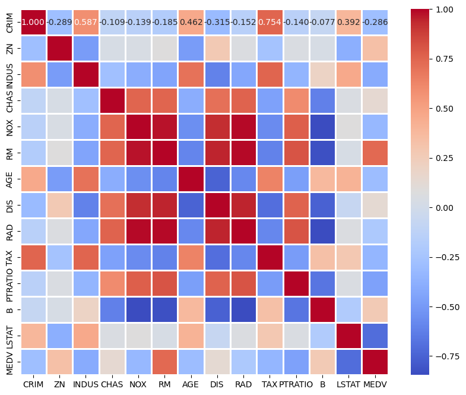

```python
corr_matrix = df.corr()
plt.figure(figsize=(10, 8))
sns.heatmap(corr_matrix, annot=True, fmt=".3f", linewidths=1, cmap="coolwarm")
```

```python
medv_corr = corr_matrix['MEDV']
medv_corr
```

```
CRIM      -0.286245
ZN         0.331570
INDUS     -0.411915
CHAS       0.136668
NOX       -0.332778
RM         0.740181
AGE       -0.299893
DIS        0.129355
RAD       -0.217902
TAX       -0.345898
PTRATIO   -0.461214
B          0.269605
LSTAT     -0.706255
MEDV       1.000000
Name: MEDV, dtype: float64
```

```python
dependent_to_medv = medv_corr[abs(medv_corr) > 0.3]
dependent_to_medv
```

```
ZN         0.331570
INDUS     -0.411915
NOX       -0.332778
RM         0.740181
TAX       -0.345898
PTRATIO   -0.461214
LSTAT     -0.706255
MEDV       1.000000
Name: MEDV, dtype: float64
```

```python
df[dependent_to_medv.index].nunique()
```

```
ZN          27
INDUS       77
NOX        132
RM         437
TAX         67
PTRATIO     85
LSTAT      445
MEDV       210
dtype: int64
```

### Q5: Scatter and Hexbin Plot for Visualizing Feature Relation to the Target

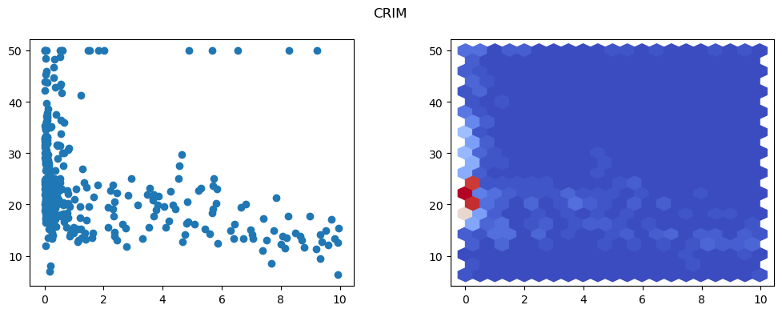

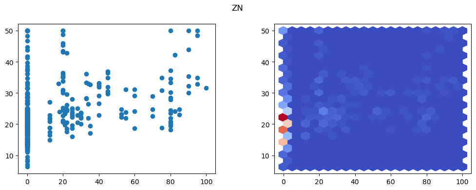

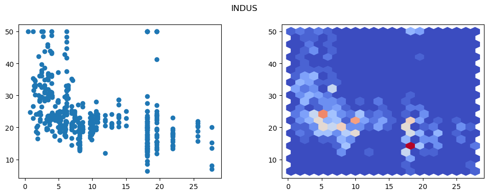

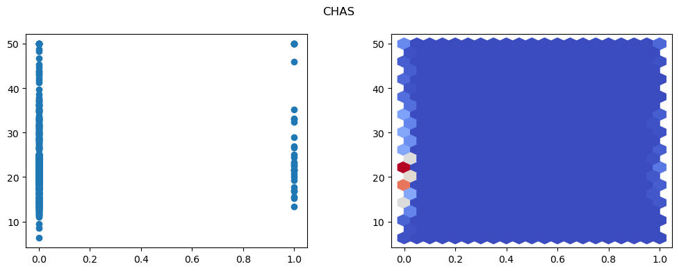

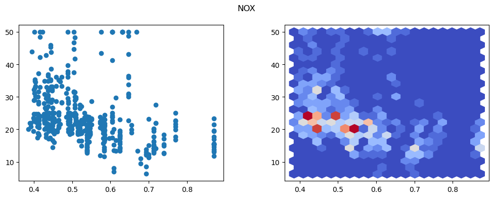

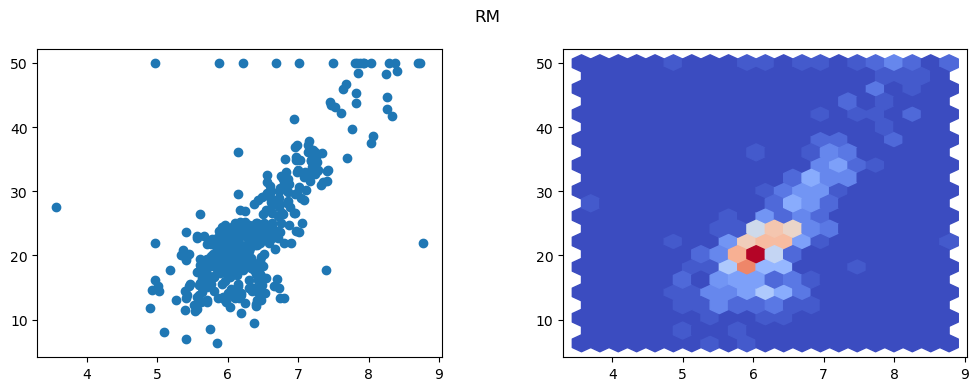

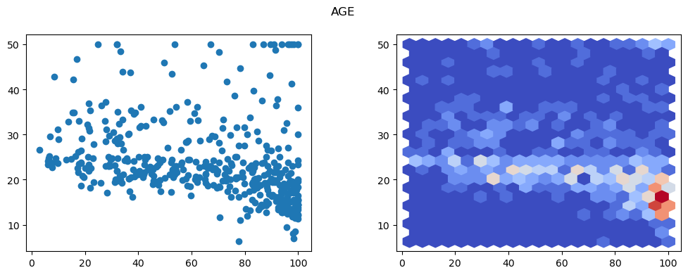

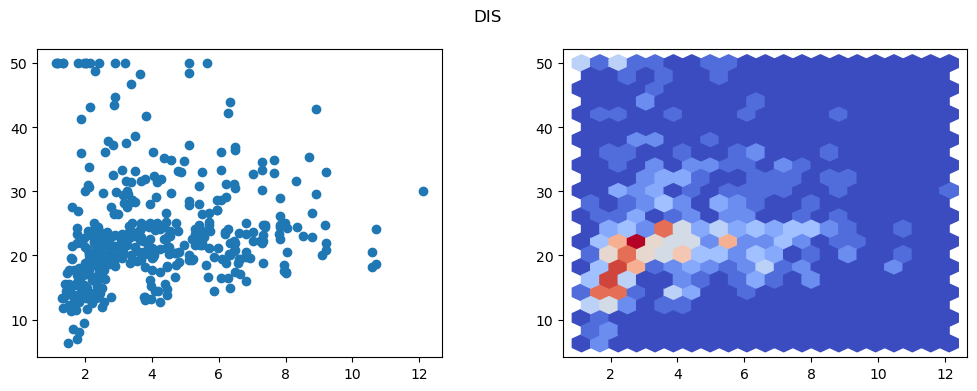

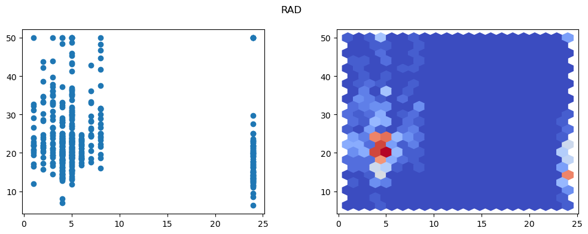

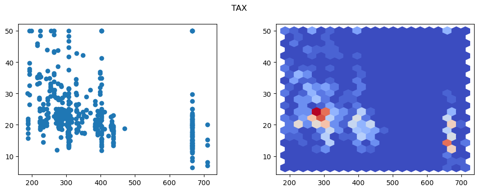

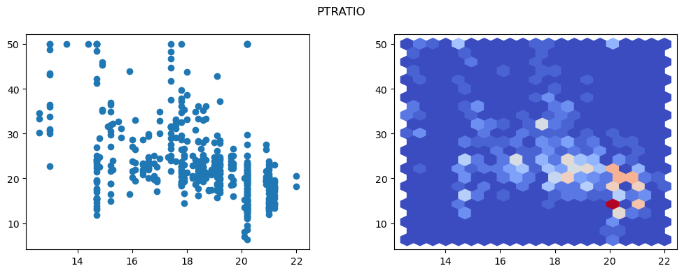

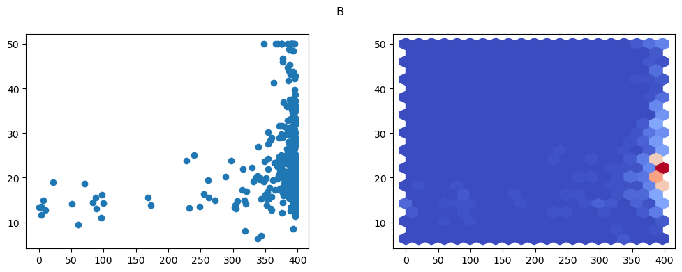

[1 more figures not shown]

```python
def plot_scatter_hexbin(feature):
    fig, axs = plt.subplots(ncols = 2, figsize = (12, 4))
    plt.suptitle(feature)
    axs[0].scatter(data = df_copy, x = feature, y = "MEDV")
    axs[1].hexbin(data = df_copy, x = feature, y = "MEDV", gridsize = 20, cmap = "coolwarm")
    plt.subplots_adjust(wspace=0.3)
    plt.show()

df_copy = deepcopy(df)
columns = df_copy.columns.drop('MEDV')
for column in columns:
    plot_scatter_hexbin(column)
```

### Q6: Suggestion for Other Data Analysis Methods

We can use **Outlier Analysis** to visualize the variables that are too far from the rest. By Analysing the outliers, we may be able to perform a better Preprocessing by omitting these values from our dataset.

In a box plot, the box represents the interquartile range (IQR), the line inside the box is the median, and the whiskers represent the range of the data within 1.5 times the IQR. Any points outside the whiskers are considered outliers.

**Caution**: Columns MEDV, B, DIS and CHAS have missing values, so drawing a boxplot for them would result in an empty box plot, that is why for purpose of visualization, I filled the missing values with median values, and then drew the boxplots.

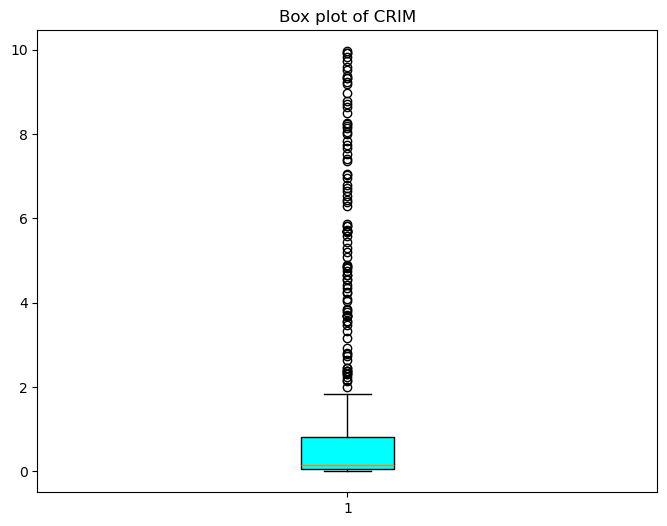

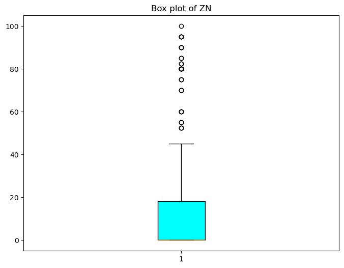

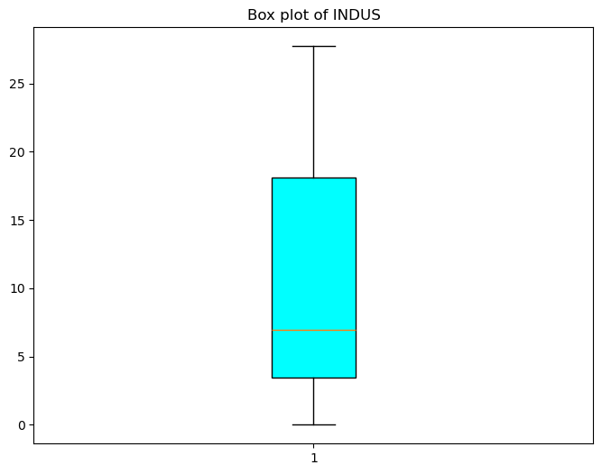

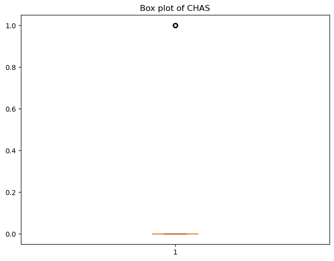

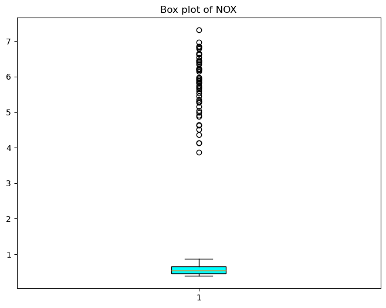

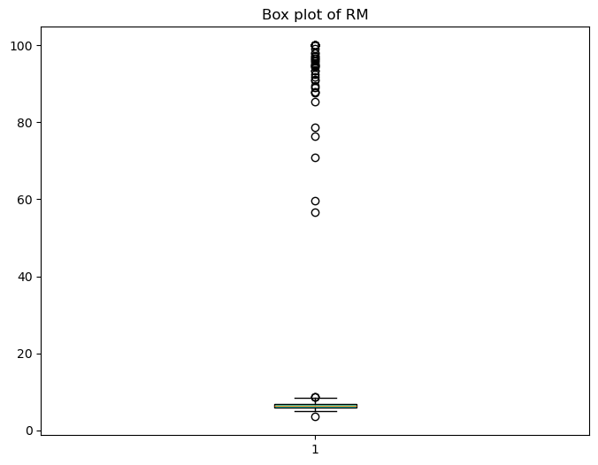

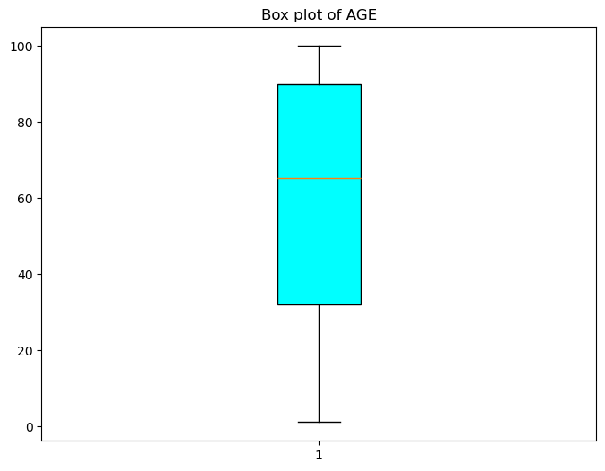

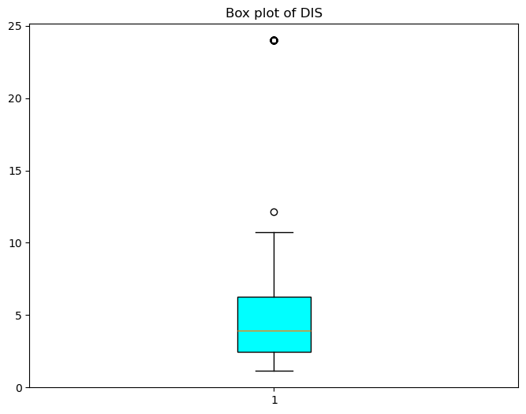

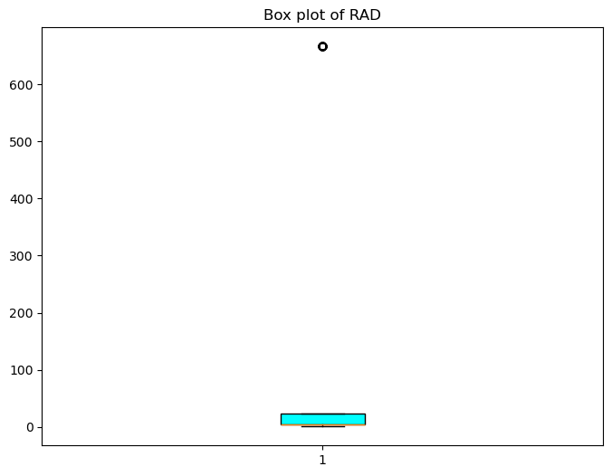

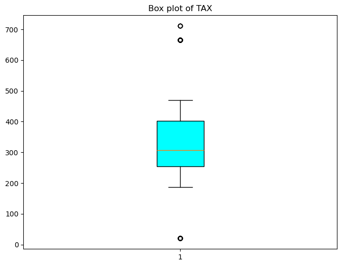

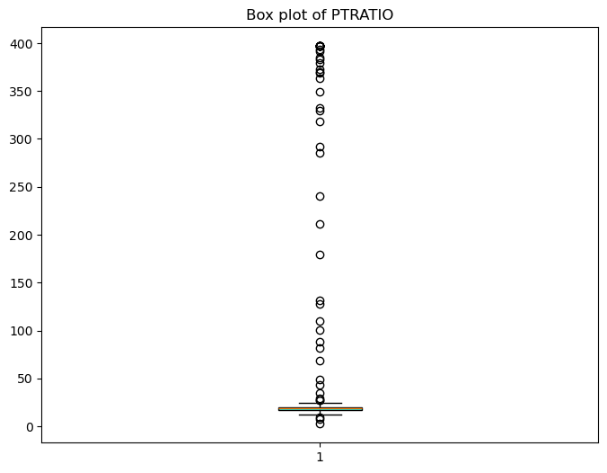

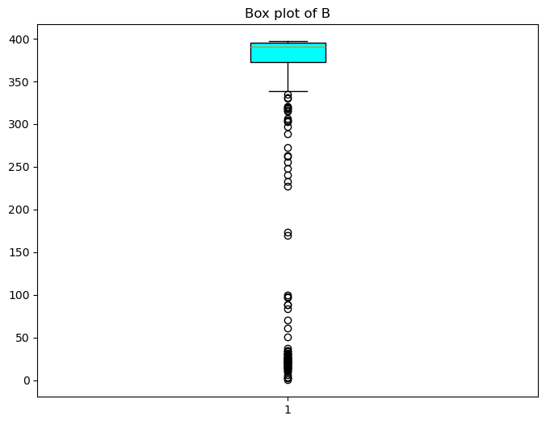

[2 more figures not shown]

```python
def draw_boxplot(column):
    if column in variables_with_na:
        df_for_boxplot[column].fillna(df_for_boxplot[column].median(), inplace = True)
    fig, ax = plt.subplots(figsize=(8, 6))
    # fig, axs = plt.subplots(ncols = 2, figsize = (12, 4))
    boxplot = ax.boxplot(df_for_boxplot[column], patch_artist = True)

    for box in boxplot['boxes']:
        box.set(facecolor = 'cyan')

    plt.title(f'Box plot of {column}')
    plt.show()

df_for_boxplot = deepcopy(df)
for column in df_for_boxplot.columns:
    draw_boxplot(column)
```

The method that I have implemented below, calculates z_score for each value in the dataframe, which is a measure of how many standard deviations an element is from the mean. Any values with a Z-score greater than the threshhold are considered outliers.

```python
z_scores = np.abs(stats.zscore(df))
outliers = np.where(z_scores > 3)
```

## Preprocessing Stage

### Q7: Filling Missing Values:

```python
# drop columns with missing values

df_for_dropping = deepcopy(df)
print(variables_with_na)
df_for_dropping.dropna(axis = 1, inplace = True)
df_for_dropping.head()
```

```
['CHAS', 'DIS', 'B', 'MEDV']
```

|  | CRIM | ZN | INDUS | NOX | RM | AGE | RAD | TAX | PTRATIO | LSTAT |
| --- | --- | --- | --- | --- | --- | --- | --- | --- | --- | --- |
| 0 | 0.00632 | 18.0 | 2.31 | 0.538 | 6.575 | 65.2 | 1 | 296.0 | 15.3 | 4.98 |
| 1 | 0.02731 | 0.0 | 7.07 | 0.469 | 6.421 | 78.9 | 2 | 242.0 | 17.8 | 9.14 |
| 2 | 0.02729 | 0.0 | 7.07 | 0.469 | 7.185 | 61.1 | 2 | 242.0 | 17.8 | 4.03 |
| 3 | 0.03237 | 0.0 | 2.18 | 0.458 | 6.998 | 45.8 | 3 | 222.0 | 18.7 | 2.94 |
| 4 | 0.06905 | 0.0 | 2.18 | 0.458 | 7.147 | 54.2 | 3 | 222.0 | 18.7 | 5.33 |

```python
# fill missing values with the median of the column

df_for_filling = deepcopy(df)
for column in variables_with_na:
    df_for_filling[column].fillna(df_for_boxplot[column].median(), inplace = True)

df_for_filling.isna().sum()
df_for_filling.head()
```

|  | CRIM | ZN | INDUS | CHAS | NOX | RM | AGE | DIS | RAD | TAX | PTRATIO | B | LSTAT | MEDV |
| --- | --- | --- | --- | --- | --- | --- | --- | --- | --- | --- | --- | --- | --- | --- |
| 0 | 0.00632 | 18.0 | 2.31 | 0.0 | 0.538 | 6.575 | 65.2 | 4.0900 | 1 | 296.0 | 15.3 | 396.900 | 4.98 | 24.0 |
| 1 | 0.02731 | 0.0 | 7.07 | 0.0 | 0.469 | 6.421 | 78.9 | 4.9671 | 2 | 242.0 | 17.8 | 396.900 | 9.14 | 21.6 |
| 2 | 0.02729 | 0.0 | 7.07 | 0.0 | 0.469 | 7.185 | 61.1 | 4.9671 | 2 | 242.0 | 17.8 | 392.830 | 4.03 | 34.7 |
| 3 | 0.03237 | 0.0 | 2.18 | 0.0 | 0.458 | 6.998 | 45.8 | 6.0622 | 3 | 222.0 | 18.7 | 390.885 | 2.94 | 33.4 |
| 4 | 0.06905 | 0.0 | 2.18 | 0.0 | 0.458 | 7.147 | 54.2 | 6.0622 | 3 | 222.0 | 18.7 | 396.900 | 5.33 | 36.2 |

### Q8: Which columns be dropped?

```python
# only drop columns with a correlation less than 0.3 (threshhold)
df_removed_corr = deepcopy(df_for_filling)
columns_to_keep = dependent_to_medv.index
df_removed_corr = df_removed_corr[columns_to_keep]
df_removed_corr.head()
```

|  | ZN | INDUS | NOX | RM | TAX | PTRATIO | LSTAT | MEDV |
| --- | --- | --- | --- | --- | --- | --- | --- | --- |
| 0 | 18.0 | 2.31 | 0.538 | 6.575 | 296.0 | 15.3 | 4.98 | 24.0 |
| 1 | 0.0 | 7.07 | 0.469 | 6.421 | 242.0 | 17.8 | 9.14 | 21.6 |
| 2 | 0.0 | 7.07 | 0.469 | 7.185 | 242.0 | 17.8 | 4.03 | 34.7 |
| 3 | 0.0 | 2.18 | 0.458 | 6.998 | 222.0 | 18.7 | 2.94 | 33.4 |
| 4 | 0.0 | 2.18 | 0.458 | 7.147 | 222.0 | 18.7 | 5.33 | 36.2 |

### Q9: Categorical and Numerical data

```python
df.dtypes
```

```
CRIM       float64
ZN         float64
INDUS      float64
CHAS       float64
NOX        float64
RM         float64
AGE        float64
DIS        float64
RAD          int64
TAX        float64
PTRATIO    float64
B          float64
LSTAT      float64
MEDV       float64
dtype: object
```

### Q10: Normalization/ Standardization:

Normalization and standardization are techniques used to preprocess numerical data before feeding it into machine learning algorithms.

Normalization scales the numerical features to a standard range, typically between 0 and 1, or -1 and 1. This transformation maintains the relative relationships between the different features while ensuring that each feature is on a similar scale. It helps in reducing the impact of outliers and ensures that the algorithm converges faster.

Standardization, on the other hand, scales the features so that they have a mean of 0 and a standard deviation of 1. This transformation makes the data more Gaussian-like and makes it easier for the algorithm to process. It also helps in reducing the impact of outliers and makes the model more robust.

In summary, normalization and standardization help in improving the performance of machine learning algorithms by ensuring that the features are on a similar scale and reducing the impact of outliers.

```python
class DataScaler:
    def __init__(self, df: pd.DataFrame):
        self.df = df
        self.numeric_cols = df.select_dtypes(include="number")
        self.scaler_std = StandardScaler()
        self.scaler_norm = MinMaxScaler()

    def standardization(self, exclude_cols: list = []):
        self.df[self.numeric_cols.columns] = self.scaler_std.fit_transform(self.numeric_cols)
        self.df[exclude_cols] = self.numeric_cols[exclude_cols]

    def normalization(self, exclude_cols: list = []):
        self.df[self.numeric_cols.columns] = self.scaler_norm.fit_transform(self.numeric_cols)
        self.df[exclude_cols] = self.numeric_cols[exclude_cols]

scalar = DataScaler(df_removed_corr)
```

```python
scalar.normalization(exclude_cols=["MEDV"])
scalar.df.describe()
```

|  | ZN | INDUS | NOX | RM | TAX | PTRATIO | LSTAT | MEDV |
| --- | --- | --- | --- | --- | --- | --- | --- | --- |
| count | 506.000000 | 506.000000 | 506.000000 | 506.000000 | 506.000000 | 506.000000 | 506.000000 | 506.000000 |
| mean | 0.132953 | 0.331837 | 0.103374 | 0.125663 | 0.461954 | 0.101484 | 0.300116 | 23.558300 |
| std | 0.230487 | 0.258458 | 0.237730 | 0.282253 | 0.261537 | 0.222128 | 0.185585 | 8.342912 |
| min | 0.000000 | 0.000000 | 0.000000 | 0.000000 | 0.000000 | 0.000000 | 0.000000 | 6.300000 |
| 25% | 0.000000 | 0.124009 | 0.009238 | 0.024891 | 0.338448 | 0.036520 | 0.157512 | 19.000000 |
| 50% | 0.000000 | 0.250901 | 0.022084 | 0.028635 | 0.415171 | 0.041339 | 0.264688 | 21.950000 |
| 75% | 0.181000 | 0.652487 | 0.037818 | 0.035131 | 0.554140 | 0.044636 | 0.406518 | 25.000000 |
| max | 1.000000 | 1.000000 | 1.000000 | 1.000000 | 1.000000 | 1.000000 | 1.000000 | 50.000000 |

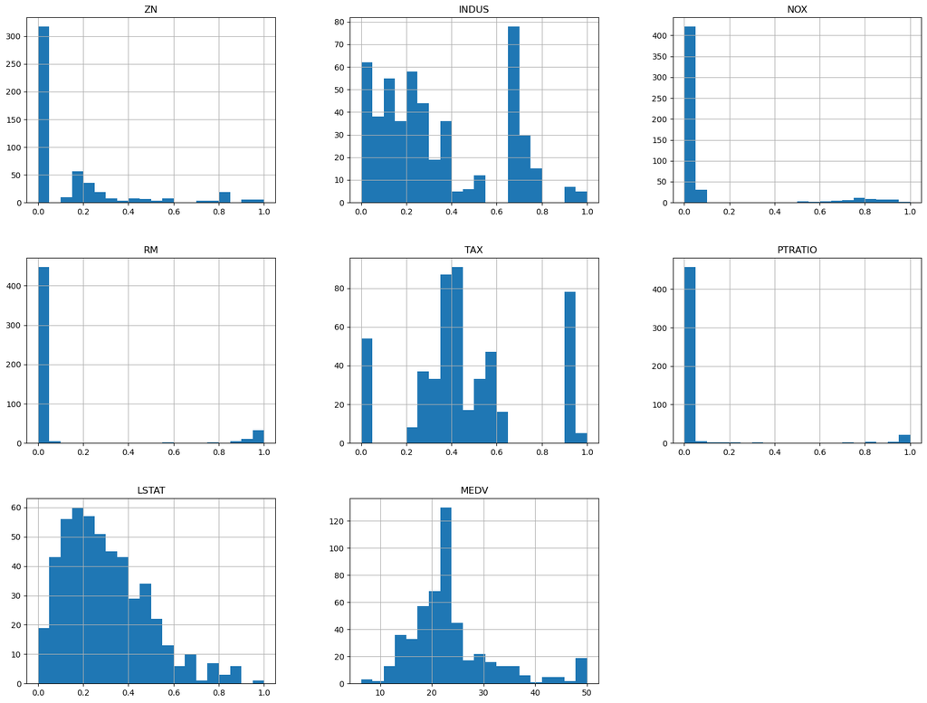

```python
scalar.df.hist(bins=20, figsize=(20,15))
plt.show()
```

### Q11: How to handel categorical data?

There are several preprocessing techniques that can be used to handle categorical data before feeding it into machine learning algorithms. Some common techniques include:

1. Encoding:
- Label encoding: Assigning a unique integer to each category in a feature. However, this can introduce ordinal relationships that may not exist in the data.
- One-Hot encoding: Creating binary columns for each category in a feature. Each column represents a category, with a value of 1 indicating the presence of that category and 0 indicating absence.
2. Target encoding: Replacing each category with the mean of the target variable for that category.
3. Frequency encoding: Replacing each category with the frequency of that category in the dataset.
4. Binary encoding: Convert categories into binary features.
5. Embedding: Representing categories as dense vectors in a high-dimensional space, where the similarity between categories is captured.

Each preprocessing technique has its own advantages and disadvantages, and the choice of technique depends on the specific dataset and machine learning algorithm being used. It is important to experiment with different techniques and evaluate their performance to determine the most effective preprocessing method for a given dataset.

```python
new_df = scalar.df
```

### Q12: Test, Train, Validation:

Testing data are used to test the model. Training data is used to train the model, and there is a section called Validation data, is used to evaluate performance of the machine learning model during training. During the model development process, the training data is used to train the model, the validation data is used to tune the model hyperparameters and assess its performance, and the test data is used to evaluate the final model performance.

The validation data helps in preventing overfitting by providing an independent dataset for evaluating the model's performance. By using separate training and validation sets, you can assess the model's generalization ability and make adjustments to the model to improve its performance.

```python
# X_train, X_test, y_train, y_test = train_test_split(X, y, test_size=0.2, random_state=42)

# # Further split the training set into training and validation sets
# X_train, X_val, y_train, y_val = train_test_split(X_train, y_train, test_size=0.25, random_state=42)
```

```python
features = new_df.drop('MEDV', axis = 1)

X_train, X_test, y_train, y_test = train_test_split(features, new_df['MEDV'], test_size = 0.2, random_state = 42)
```

```python
display(X_train)
display(y_train)
```

|  | ZN | INDUS | NOX | RM | TAX | PTRATIO | LSTAT |
| --- | --- | --- | --- | --- | --- | --- | --- |
| 477 | 0.181 | 0.000000 | 0.710017 | 0.972003 | 0.000000 | 0.879736 | 0.314259 |
| 15 | 0.000 | 0.293439 | 0.022084 | 0.023569 | 0.415171 | 0.046665 | 0.206242 |
| 332 | 0.350 | 0.218457 | 0.007636 | 0.025612 | 0.410828 | 0.036267 | 0.186659 |
| 423 | 0.000 | 0.652487 | 0.033054 | 0.026359 | 0.934858 | 0.044636 | 0.659731 |
| 19 | 0.000 | 0.293439 | 0.022084 | 0.022460 | 0.415171 | 0.046665 | 0.292228 |
| ... | ... | ... | ... | ... | ... | ... | ... |
| 106 | 0.000 | 0.308580 | 0.019486 | 0.023590 | 0.526636 | 0.046411 | 0.518054 |
| 270 | 0.200 | 0.250901 | 0.011403 | 0.023797 | 0.293573 | 0.040578 | 0.344859 |
| 348 | 0.800 | 0.072459 | 0.007217 | 0.031875 | 0.376086 | 0.036520 | 0.130355 |
| 435 | 0.181 | 0.000000 | 0.901270 | 0.944006 | 0.000000 | 0.272001 | 0.357099 |
| 102 | 0.000 | 0.308580 | 0.019486 | 0.029490 | 0.526636 | 0.046411 | 0.272338 |

404 rows × 7 columns

```
477    21.95
15     19.90
332    19.40
423    13.40
19     18.20
       ...
106    19.50
270    21.10
348    24.50
435    21.95
102    18.60
Name: MEDV, Length: 404, dtype: float64
```

```python
X_test
```

|  | ZN | INDUS | NOX | RM | TAX | PTRATIO | LSTAT |
| --- | --- | --- | --- | --- | --- | --- | --- |
| 173 | 0.000 | 0.145999 | 0.018043 | 0.029604 | 0.399247 | 0.035506 | 0.223684 |
| 274 | 0.400 | 0.231074 | 0.008949 | 0.033150 | 0.338448 | 0.038042 | 0.055080 |
| 491 | 0.000 | 1.000000 | 0.032333 | 0.025114 | 1.000000 | 0.044382 | 0.500000 |
| 72 | 0.000 | 0.389690 | 0.004042 | 0.025965 | 0.412276 | 0.042100 | 0.115973 |
| 452 | 0.000 | 0.652487 | 0.047344 | 0.028370 | 0.934858 | 0.044636 | 0.475520 |
| ... | ... | ... | ... | ... | ... | ... | ... |
| 412 | 0.181 | 0.000000 | 0.612442 | 1.000000 | 0.000000 | 0.066422 | 0.494798 |
| 436 | 0.181 | 0.000000 | 0.877021 | 0.930526 | 0.000000 | 0.063125 | 0.240820 |
| 411 | 0.181 | 0.000000 | 0.905312 | 1.000000 | 0.000000 | 0.082298 | 0.473378 |
| 86 | 0.000 | 0.161860 | 0.009238 | 0.025446 | 0.328315 | 0.040325 | 0.340575 |
| 75 | 0.000 | 0.462509 | 0.007506 | 0.028256 | 0.546902 | 0.040832 | 0.220624 |

102 rows × 7 columns

### Q13: Other examples of preprocessing:

Z-score that I have implemented above, Dimension Reduction methods like PC that I have used in Clustering project, and also preprocessing techniques like stopwords, lemmatization and ... that I have implemented in NLP project.

### Q14: Supervised learning, Unsupervised learning, Reinfrocement Learning:

Supervised Learning: Labeled Dataset, like Classification, NN, Logistic Regression

UnSupervised Learning: Not Labeled Dataset, like Clustering Project

RL: Reinforcement Learning is a type of machine learning where an agent learns to make decisions by interacting with an environment, receiving rewards or penalties based on its actions.

### Q15: What is Regression and What is the difference from Classification?

The main difference between regression and classification is the type of output they predict. Regression predicts continuous numerical values, while classification predicts discrete class labels.

In regression, the output variable is continuous and can take any numerical value within a range. In classification, the output variable is categorical and belongs to a specific class or category.

Regression algorithms are evaluated using metrics like Mean Squared Error (MSE), Root Mean Squared Error (RMSE), or R-squared, while classification algorithms are evaluated using metrics like accuracy, precision, recall, and F1 score.

The choice between regression and classification depends on the nature of the problem and the type of output needed. If the goal is to predict a numeric value, regression is used. If the goal is to classify data into categories, classification is used.

### Q16: Linear Regression:

Explain the codes

# Linear Regression

Main form of simple linear regression function: $$f(x) = \alpha x + \beta$$

- step 1: Compute RSS of the training data

$$ RSS = \Sigma (y_i - (\hat{\beta} + \hat{\alpha} * x_i) )^2 $$

- step 2: Compute the derivatives of the RSS function in terms of $\alpha$ and $\beta$, and set them equal to 0 to find the desired parameters

$$ \frac{\partial RSS}{\partial \beta} = \Sigma (-f(x_i) + \hat{\beta} + \hat{\alpha} * x_i) = 0$$$$ \to \beta = \hat{y} - \hat{\alpha} \hat{x} \to (1)$$$$ \frac{\partial RSS}{\partial \alpha} = \Sigma (-2 x_i y_i + 2 \hat{\beta} x_i + 2\hat{\alpha} x_i ^ 2) = 0 \to (2)$$$$ (1) , (2) \to \hat{\alpha} = \frac{\Sigma{(x_i - \hat{x})(y_i - \hat{y})}}{\Sigma{(x_i - \hat{x})^2}} $$$$ \hat{\beta} = y - \hat{a} x$$

Based on the above formula, implement the function below to compute the parameters of a simple linear regression

```python
def linear_regression(input_feature, output):
    Sxy = (input_feature * output).sum() - input_feature.sum() * output.sum() / len(output)
    Sxx = (input_feature ** 2).sum() - (input_feature.sum())**2 / len(output)
    slope = Sxy / Sxx
    intercept = output.mean() - slope * input_feature.mean()
    return (intercept, slope)
```

Now complete this `get_regression_predictions(...)` function to predict the value of given data based on the calculated intercept and slope

```python
def get_regression_predictions(input_feature, intercept, slope):
    return input_feature * slope + intercept
```

Now that we have a model and can make predictions, let's evaluate our model using Root Mean Square Error (RMSE). RMSE is the square root of the mean of the squared differences between the residuals, and the residuals is just a fancy word for the difference between the predicted output and the true output.

Complete the following function to compute the RSME of a simple linear regression model given the input_feature, output, intercept and slope:

```python
def get_root_mean_square_error(predicted_values, actual_values):
    residuals = predicted_values - actual_values
    residuals_sum_sqr = (residuals ** 2).sum()
    mean_residual_sqr = residuals_sum_sqr/len(predicted_values)
    return math.sqrt(mean_residual_sqr)
```

The RMSE has no bound, thus it becomes challenging to determine whether a particular RMSE value is considered good or bad without any reference point. Instead, we use R2 score. The R2 score is calculated by comparing the sum of the squared differences between the actual and predicted values of the dependent variable to the total sum of squared differences between the actual and mean values of the dependent variable. The R2 score is formulated as below:

$$R^2 = 1 - \frac{SSres}{SStot} = 1 - \frac{\sum_{i=1}^{n} (y_{i,true} - y_{i,pred})^2}{\sum_{i=1}^{n} (y_{i,true} - \bar{y}_{true})^2} $$

Complete the following function to calculate the R2 score of a given input_feature, output, bias, and slope:

```python
def get_r2_score(predicted_values, actual_values):
    residuals = predicted_values - actual_values
    SSres = (residuals ** 2).sum()
    SStot = ((actual_values - actual_values.mean())**2).sum()
    return 1 - SSres / SStot
```

Now calculate the fitness of the model. Remember to provide explanation for the outputs in your code!

```python
def test_simple_linear_regression(feature, ax):
    intercept, slope = linear_regression(X_train[feature], y_train)
    predicted_values = get_regression_predictions(X_test[feature], intercept, slope)
    rmse = get_root_mean_square_error(predicted_values, y_test)
    r2_score = get_r2_score(predicted_values, y_test)
    print(f"{feature}:\n RMSE: {rmse:0.3f}, R^2: {r2_score}")

    # ax.scatter(X_train[feature], y_train)
    # x_line = np.linspace(min(df[feature]), max(df[feature]), 100)
    # y_line = intercept + slope * x_line
    # ax.plot(x_line, y_line, color='red', label = f"y = {slope:0.2f} * x + {intercept:0.2f}")

    # ax.set_ylabel("MEDV")
    # #ax.set_xlabel(feature)
    # ax.set_title(feature)
    # ax.legend()
    bias, slope = linear_regression(X_train[feature], y_train)
    predicted_values = get_regression_predictions(X_train[feature], bias, slope)

    ax.scatter(X_train[feature], y_train)
    x_line = np.linspace(min(X_train[feature]), max(X_train[feature]), 100)
    y_line = bias * x_line + slope
    ax.plot(x_line, y_line, color='red', label = f"y = {bias:0.3f} * x + {slope:0.3f}")
    ax.plot(x_line, x_line, color='gray', linestyle='--', label="y = x (Identity line)")
    ax.set_ylabel("MEDV")
    ax.set_xlabel(feature)
    ax.set_title(feature)
    ax.legend()
    plt.show
```

```python
X_train
```

|  | ZN | INDUS | NOX | RM | TAX | PTRATIO | LSTAT |
| --- | --- | --- | --- | --- | --- | --- | --- |
| 477 | 0.181 | 0.000000 | 0.710017 | 0.972003 | 0.000000 | 0.879736 | 0.314259 |
| 15 | 0.000 | 0.293439 | 0.022084 | 0.023569 | 0.415171 | 0.046665 | 0.206242 |
| 332 | 0.350 | 0.218457 | 0.007636 | 0.025612 | 0.410828 | 0.036267 | 0.186659 |
| 423 | 0.000 | 0.652487 | 0.033054 | 0.026359 | 0.934858 | 0.044636 | 0.659731 |
| 19 | 0.000 | 0.293439 | 0.022084 | 0.022460 | 0.415171 | 0.046665 | 0.292228 |
| ... | ... | ... | ... | ... | ... | ... | ... |
| 106 | 0.000 | 0.308580 | 0.019486 | 0.023590 | 0.526636 | 0.046411 | 0.518054 |
| 270 | 0.200 | 0.250901 | 0.011403 | 0.023797 | 0.293573 | 0.040578 | 0.344859 |
| 348 | 0.800 | 0.072459 | 0.007217 | 0.031875 | 0.376086 | 0.036520 | 0.130355 |
| 435 | 0.181 | 0.000000 | 0.901270 | 0.944006 | 0.000000 | 0.272001 | 0.357099 |
| 102 | 0.000 | 0.308580 | 0.019486 | 0.029490 | 0.526636 | 0.046411 | 0.272338 |

404 rows × 7 columns

### Q18: RMSE, R2, MSE, RSS:

Mean Squared Error (MSE): Mean Squared Error (MSE) is a common metric used to measure the average squared difference between the actual target values and the predicted values by the linear regression model.

Residual Sum of Squares (RSS) is another metric used to measure the sum of squared differences between the actual target values and the predicted values by the linear regression model.

```
ZN:
 RMSE: 6.723, R^2: 0.2360969806281028
INDUS:
 RMSE: 7.114, R^2: 0.1446586625620616
NOX:
 RMSE: 7.777, R^2: -0.0223036922984865
RM:
 RMSE: 7.782, R^2: -0.023766231676312755
TAX:
 RMSE: 7.428, R^2: 0.06736632137571663
PTRATIO:
 RMSE: 7.779, R^2: -0.022810390851953688
LSTAT:
 RMSE: 5.550, R^2: 0.47932354419801504
```

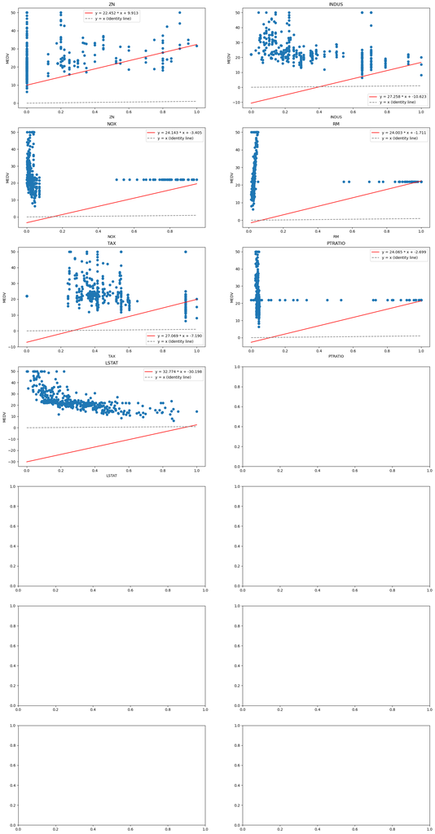

```python
# designated_feature_list =  list(dependent_to_medv.index)
designated_feature_list = [feature for feature in dependent_to_medv.index if feature != 'MEDV']
fig, axs = plt.subplots(nrows=7, ncols=2, figsize=(20,40))
axs = axs.flatten()

for ax, feature in zip(axs, designated_feature_list):
    test_simple_linear_regression(feature, ax)
```

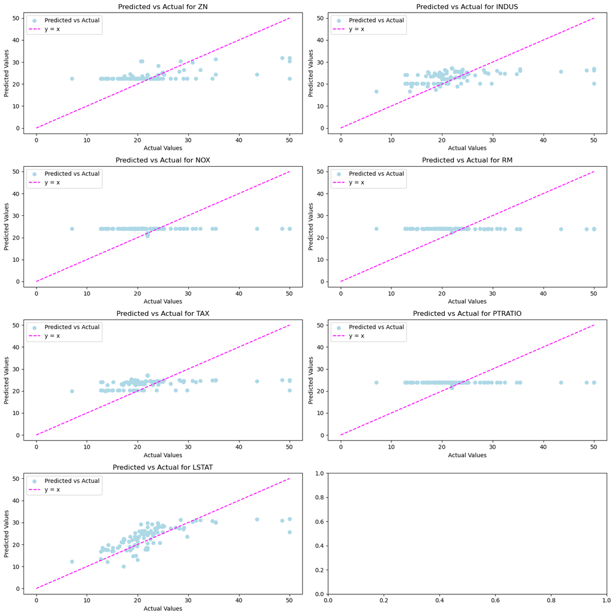

```python
def compare_predicted_actual(feature, ax):
    bias, slope = linear_regression(X_train[feature], y_train)
    predicted_values = get_regression_predictions(X_test[feature], bias, slope)
    ax.scatter(y_test, predicted_values, color='lightblue', label='Predicted vs Actual')
    ax.plot([0, max(y_test)], [0, max(y_test)], color=(1.0, 0.0, 1.0), linestyle='--', label='y = x')
    ax.set_xlabel('Actual Values')
    ax.set_ylabel('Predicted Values')
    ax.set_title(f'Predicted vs Actual for {feature}')
    ax.legend()


fig, axs = plt.subplots(nrows=4, ncols=2, figsize=(15,15))
axs = axs.flatten()

for ax, feature in zip(axs, designated_feature_list):
    compare_predicted_actual(feature, ax)

plt.tight_layout()
plt.show()
```

## Classification

```python
def categorize_based_on_medv(df):
    luxury_thresh = df['MEDV'].quantile(0.8)
    economic_thresh = df['MEDV'].quantile(0.2)

    #normal = 0 luxury = 1 economic = 2
    df['MEDV Category'] = 0
    df.loc[df['MEDV'] > luxury_thresh, 'MEDV Category'] = 1
    df.loc[df['MEDV'] < economic_thresh, 'MEDV Category'] = 2
    return df


categorized_df = categorize_based_on_medv(new_df)
features = categorized_df.drop(["MEDV", "MEDV Category"], axis = "columns")
X_train, X_test, y_train, y_test = train_test_split(features, categorized_df["MEDV Category"], test_size = 0.2, random_state = 42)
display(X_train)
display(y_train)
```

|  | ZN | INDUS | NOX | RM | TAX | PTRATIO | LSTAT |
| --- | --- | --- | --- | --- | --- | --- | --- |
| 477 | 0.181 | 0.000000 | 0.710017 | 0.972003 | 0.000000 | 0.879736 | 0.314259 |
| 15 | 0.000 | 0.293439 | 0.022084 | 0.023569 | 0.415171 | 0.046665 | 0.206242 |
| 332 | 0.350 | 0.218457 | 0.007636 | 0.025612 | 0.410828 | 0.036267 | 0.186659 |
| 423 | 0.000 | 0.652487 | 0.033054 | 0.026359 | 0.934858 | 0.044636 | 0.659731 |
| 19 | 0.000 | 0.293439 | 0.022084 | 0.022460 | 0.415171 | 0.046665 | 0.292228 |
| ... | ... | ... | ... | ... | ... | ... | ... |
| 106 | 0.000 | 0.308580 | 0.019486 | 0.023590 | 0.526636 | 0.046411 | 0.518054 |
| 270 | 0.200 | 0.250901 | 0.011403 | 0.023797 | 0.293573 | 0.040578 | 0.344859 |
| 348 | 0.800 | 0.072459 | 0.007217 | 0.031875 | 0.376086 | 0.036520 | 0.130355 |
| 435 | 0.181 | 0.000000 | 0.901270 | 0.944006 | 0.000000 | 0.272001 | 0.357099 |
| 102 | 0.000 | 0.308580 | 0.019486 | 0.029490 | 0.526636 | 0.046411 | 0.272338 |

404 rows × 7 columns

```
477    0
15     0
332    0
423    2
19     0
      ..
106    0
270    0
348    0
435    0
102    0
Name: MEDV Category, Length: 404, dtype: int64
```

### Q21: Pruning

Pruning in decision trees is a technique used, in order to avoid extra complications during classification. It is also used as to avoid overfitting.

Pruning is a technique used to prevent overfitting in decision trees and other tree-based models. Pruning involves cutting back or removing parts of the tree that are not necessary or do not contribute significantly to the model's predictive performance. Here are some pros and cons of pruning in the context of decision trees:

Pros of Pruning:

1. Prevents Overfitting: One of the main advantages of pruning is that it helps prevent overfitting, where the model learns noise or irrelevant patterns in the training data. By simplifying the tree structure and removing unnecessary branches, pruning can lead to a more generalized model that performs better on unseen data.
2. Improves Model Interpretability: Pruning can simplify the decision tree structure by removing redundant or irrelevant nodes, making the tree easier to interpret and understand. A simpler tree structure can help in identifying the most important features and decision paths that impact the model's predictions.
3. Reduces Computational Complexity: Pruning can reduce the size and complexity of the decision tree, making it more efficient in terms of memory and processing power. A smaller tree requires less computational resources during training and prediction, leading to faster model training and inference times.
4. Enhances Model Performance: Pruning can improve the overall performance of the model by focusing on the most relevant features and decision nodes that contribute to accurate predictions. By removing noise and irrelevant details, the pruned tree can provide better generalization and predictive power.

Cons of Pruning:

1. Loss of Information: Pruning a decision tree removes branches and nodes, which may result in loss of information or predictive power. If important decision paths or features are pruned too aggressively, it can lead to a decrease in the model's accuracy on unseen data.
2. Requires Tuning Parameters: Pruning involves hyperparameters that need to be tuned, such as the pruning threshold or criterion for node removal. Finding the optimal pruning strategy can be challenging and may require experimentation to balance model complexity and predictive accuracy.
3. Potential Underfitting: Over-pruning a decision tree can lead to underfitting, where the model is too simplified and lacks the capacity to capture complex patterns in the data. A pruned tree that is too shallow may not capture all the relevant features and relationships present in the dataset.
4. Sensitivity to Data Variability: Pruning can be sensitive to variations in the training data, and the optimal pruning strategy may vary depending on the dataset and its characteristics. Different datasets may require different pruning techniques to achieve the best performance.

In conclusion, pruning is a valuable technique for improving the generalization and performance of decision trees by preventing overfitting and simplifying the model structure. However, it also has drawbacks, such as potential loss of information, sensitivity to hyperparameters, and the risk of underfitting. Careful consideration and experimentation are needed to effectively use pruning in tree-based models.

### Q22: When is DT better than other models?

Decision Trees (DT) have several advantages that make them suitable for certain scenarios compared to other machine learning models. Here are some cases where Decision Trees might be better suited than other models:

1. Interpretability: Decision Trees provide a clear and easy-to-understand representation of the decision-making process. The tree structure with branches and nodes can be visually interpreted, making it useful for explaining and communicating the model's logic to stakeholders or non-technical users. In contrast, complex models like Neural Networks or Support Vector Machines may be harder to interpret.
2. Handling Non-linear Relationships: Decision Trees are capable of capturing non-linear relationships between features and the target variable without the need for feature engineering or transformations. They can naturally handle interactions and non-linearities in the data, making them suitable for datasets with complex decision boundaries.
3. Feature Importance: Decision Trees inherently provide a feature importance ranking based on the information gain or Gini impurity reduction at each split. This feature importance can help identify the most relevant predictors in the dataset, aiding in feature selection and understanding the key factors influencing the model's predictions.
4. Robustness to Outliers and Missing Values: Decision Trees are robust to outliers and missing values in the data. They can handle irregularities in the dataset without significantly affecting the model's performance, as each decision is made based on available features and does not rely on specific statistical assumptions.
5. Scalability: Decision Trees can handle both categorical and numerical features efficiently, making them scalable to large datasets with mixed data types. Training a Decision Tree model is generally faster than complex models like Neural Networks for smaller to medium-sized datasets.
6. Easy to Implement and Visualize: Decision Trees are relatively easy to implement and interpret, requiring minimal data preprocessing compared to some other models. Visualization tools can be used to visualize the tree structure, helping in understanding the decision-making process and identifying patterns in the data.
7. Ensembling Techniques: Decision Trees can be easily combined with ensemble methods like Random Forests or Gradient Boosting to improve predictive performance. Ensemble methods leverage the strengths of individual trees while mitigating their weaknesses, resulting in more accurate and robust models.

Although Decision Trees have various advantages, they also have limitations such as tendency to overfit, sensitivity to small variations in the data, and lack of predictive accuracy compared to more complex models in certain scenarios. It is essential to consider the specific characteristics of the dataset and the problem at hand when choosing the appropriate model for a given task.

### Descision Tree Classefier

```python
from abc import ABC, abstractmethod
from sklearn import metrics
from sklearn.model_selection import GridSearchCV

class ClassifierModel(ABC):
    def __init__(self, X_train, y_train, params):
        self.X_train = X_train
        self.y_train = y_train
        self.classifier = self.create_classifier(params)
        self.search_params = self.set_search_params()
        self.classifier.fit(X_train, y_train)
        self.train_accuracy = self.calc_accuracy(X_train, y_train)

    @abstractmethod
    def create_classifier(self, params):
        pass

    @abstractmethod
    def set_search_params(self):
        pass

    def predict(self, data):
        return self.classifier.predict(data)

    def get_train_accuracy(self):
        return self.train_accuracy

    def calc_accuracy(self, X_test, y_test):
        preds = self.predict(X_test)
        accuracy = metrics.accuracy_score(y_test, preds)
        return accuracy

    def grid_search(self, X_train, y_train, X_test, y_test):
        grid = GridSearchCV(self.classifier, self.search_params, scoring='accuracy', n_jobs = 2)
        grid.fit(X_train, y_train)
        test_score = grid.score(X_test, y_test)
        return grid, test_score

    def draw_confusion_matrix(self, X_test, y_test):
        preds = self.classifier.predict(X_test)
        confusion_matrix = metrics.confusion_matrix(y_test, preds)
        fig, ax = plt.subplots(figsize=(8, 6))
        matrix_plot = metrics.ConfusionMatrixDisplay(confusion_matrix)
        matrix_plot.plot(cmap='coolwarm', ax = ax)
        plt.title('Confusion Matrix')
        plt.show()
```

```python
def run_model(Model, X_train, y_train, X_test, y_test, params):
    model = Model(X_train, y_train, params)
    print(f"model's train accuracy: {model.get_train_accuracy(): 0.3f}")
    print(f"model's test accuracy: {model.calc_accuracy(X_test, y_test): 0.3f}")
    grid, test_score = model.grid_search(X_train, y_train, X_test, y_test)
    print(f"Best hyperparameters: {grid.best_params_}")
    print(f"Best model's train accuracy score: {grid.best_score_:0.3f}")
    print(f"Best model's test score: {test_score:0.3f}")
    model.draw_confusion_matrix(X_test, y_test)
```

```python
from sklearn.tree import DecisionTreeClassifier, plot_tree
from sklearn.tree import DecisionTreeRegressor

class DecisionTreeModel(ClassifierModel):

    def create_classifier(self, params):
        return DecisionTreeClassifier(criterion = params["criterion"], max_depth = params["max_depth"],
                                      min_samples_split = params["min_samples_split"], min_samples_leaf = params["min_samples_leaf"])

    def draw_tree(self):
        class_names = [str(cls) for cls in self.y_train.unique()]
        fig, ax = plt.subplots(figsize=(12, 8))  # Adjust the size as needed
        plot_tree(self.classifier, filled=True, ax=ax,  feature_names = self.X_train.columns, class_names = class_names)
        plt.title('Decision Tree')
        plt.show()


    def set_search_params(self):
        return {
            'criterion': ["gini", "entropy"],
            'max_depth': range(5, 10),
            'min_samples_split': range(3, 10),
            'min_samples_leaf': range(1, 6),
        }
```

```
model's train accuracy:  0.913
model's test accuracy:  0.824
Best hyperparameters: {'criterion': 'entropy', 'max_depth': 6, 'min_samples_leaf': 3, 'min_samples_split': 5}
Best model's train accuracy score: 0.841
Best model's test score: 0.863
```

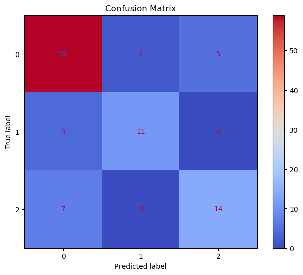

```python
params = {
        'criterion': "entropy",
        'max_depth': 8,
        'min_samples_split': 5,
        'min_samples_leaf': 8,
}
run_model(DecisionTreeModel, X_train, y_train, X_test, y_test, params)
```

### Q23: Difference of Training between algorithms such as KNN, Logistic Regression and NN:

KNN is a memory-based algorithm that does not learn a specific model during training, whereas Logistic Regression and Neural Networks involve optimization of model parameters to learn a decision boundary. Logistic Regression is a linear model with interpretable coefficients, while Neural Networks can learn complex non-linear relationships but are more computationally intensive and require optimization techniques for training. The choice of algorithm depends on the data characteristics, interpretability requirements, and the complexity of the relationship between features and the target variable.

### Q24: One-Nearest-Neighbor:

The One Nearest Neighbor (1-NN) method is a simple and intuitive instance-based learning algorithm used for classification tasks. In 1-NN, the class label of a new data point is predicted based on the class of its nearest neighbor in the training dataset. Here is an overview of how the 1-NN method works:

1. Training Phase:
   - In the training phase of the 1-NN algorithm, the entire training dataset is stored without any specific model being learned. The training data consists of feature vectors and corresponding class labels.
2. Prediction Phase:
   - Given a new data point that needs to be classified, the 1-NN algorithm calculates the distances between the new data point and all data points in the training set. Various distance metrics like Euclidean distance, Manhattan distance, or other similarity measures can be used for this purpose.
   - The nearest neighbor to the new data point is identified based on the calculated distances. The class label of the nearest neighbor is then assigned to the new data point.
3. Classification:
   - The predicted class label of the new data point is determined by the majority class of its nearest neighbor in the training set. If the majority class of the nearest neighbor is a certain class, the new data point is classified into that class.
4. Algorithm Complexity:
   - The 1-NN algorithm is simple to implement and understand, as it directly relies on the similarity of data points to make predictions. However, it can be computationally expensive for large datasets, as it requires calculating distances to all training points for each prediction.
5. Key Considerations:
   - The choice of distance metric and the number of nearest neighbors (K) can affect the performance of the 1-NN algorithm. Different distance metrics may be more suitable for specific types of data.
   - The 1-NN algorithm is sensitive to outliers and noise in the data, as the prediction is solely based on the closest neighbor. Outliers can significantly impact the classification result.
   - While 1-NN can capture complex decision boundaries in the data, it may suffer from overfitting, especially in noisy datasets with a high dimensionality. It is important to consider the balance between model complexity and generalization.

Overall, the 1-NN algorithm is a straightforward and non-parametric approach to classification that can be effective for small to moderately sized datasets with clear decision boundaries. It offers a simple yet powerful way to make predictions based on the similarity between data points, making it a valuable tool in machine learning applications.

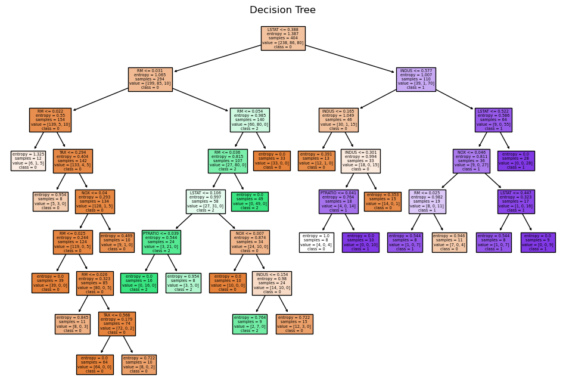

```python
decision_tree_model = DecisionTreeModel(X_train, y_train, params)
y_pred_dt = decision_tree_model.predict(X_test)
# After training the model, you can now call the draw_tree method to visualize the decision tree
decision_tree_model.draw_tree()
```